# Windows Process Priority: Impact on Batery Usage

Last Updated: November 14, 2019

# tl;dr

A series of experiments were performed to determine the impact the the Windows Process Priority Manager (`dom.ipc.processPriorityManager.enabled`) has on battery consumption. In addition, the following prefs were also tested to determine the potential degree of impact:

- `privacy.trackingprotection.enabled` (tracking protection)
- `media.autoplay.default` (block autoplay)

The Process Priority Manager has no observed impact on battery usage. However, tracking protection significantly reduces power demand, while blocking autoplay has a smaller, but measurable influence.

# Description

The experiment utilized a list of 22 URLs, used in previous [experiments](https://metrics.mozilla.com/protected/cdowhygelund/blockautoplay_analysis.html).

Start with a list of URIs:

1. Open Firefox and wait 2 seconds
2. Open the first URI and wait 60 seconds
3. Open a new tab, shift the focus, open the next URI and wait 60 seconds.
4. Repeat 3 for each URI.
5. Once each URI has been opened, shutdown Firefox.
6. Change to the next set of preferences. Do steps 1-5

The above is done five times for a given page ordering. There 10 random shuffles of the page ordering, to yield a total of 50 runs through the URIs for a set of preference settings.

# Results

## Windows Process Priority Manager

The following plot shows the cumulative processor power usage through time, with the `dom.ipc.processPriorityManager.enabled` set to `True` or `False`. The boxplots contain all values between the time range given in the x-axis. There is no observed difference through time in battery usage, in changing the preference value.

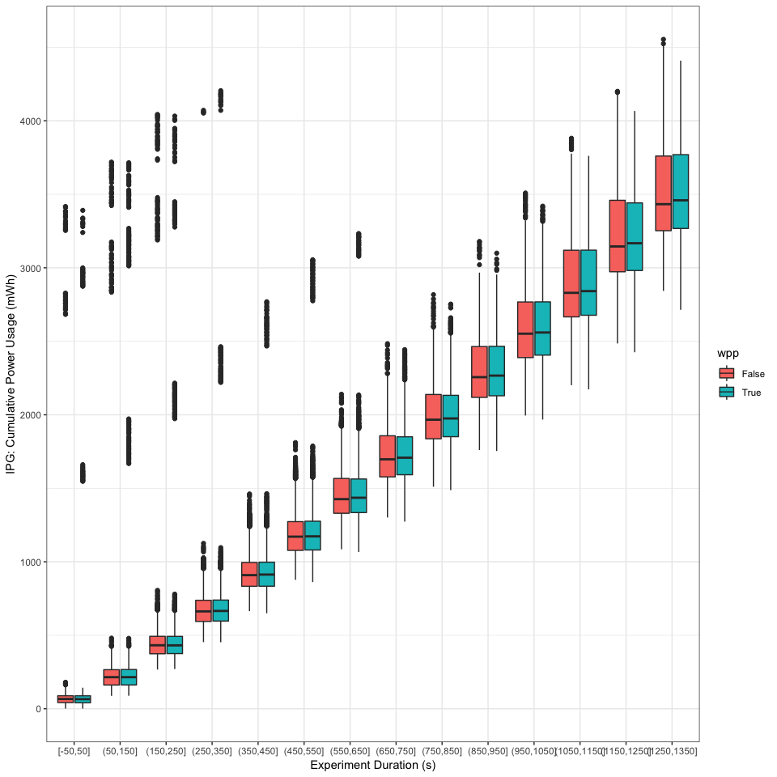

## Tracking Protection

There is a significantly reduced cumulative processor power consumption enabling the `privacy.trackingprotection.enabled`. This is observed throughout the experiment. In addition, the distribution is narrower with this preference flipped on.

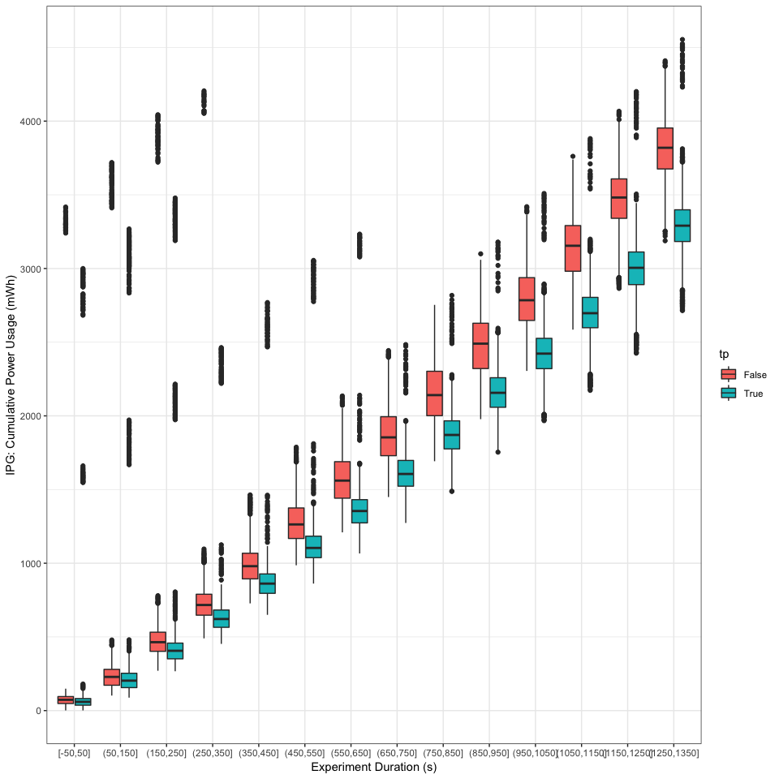

## Block Autoplay

A smaller, but significant, effect is observed for the `media.autoplay.default` preference.

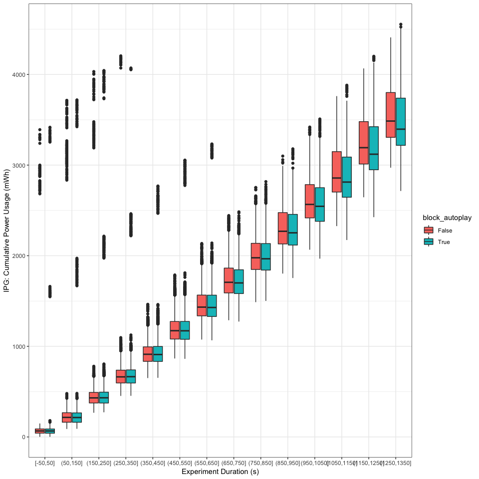